# gipr_analysis

# Data exploration of data with focus on treatment group

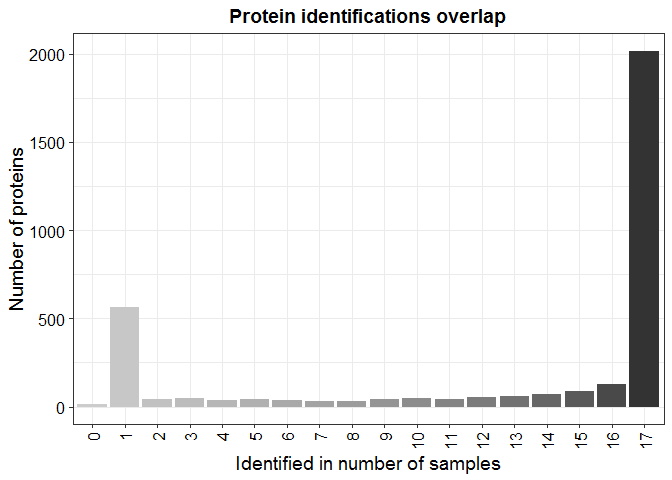

```r
plot_frequency(data_se)
```

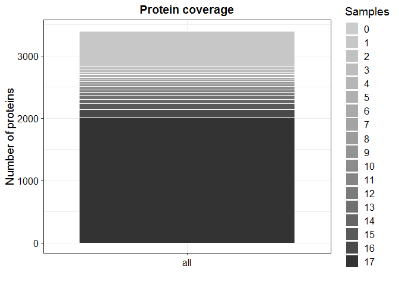

```r
plot_coverage(data_se)
```

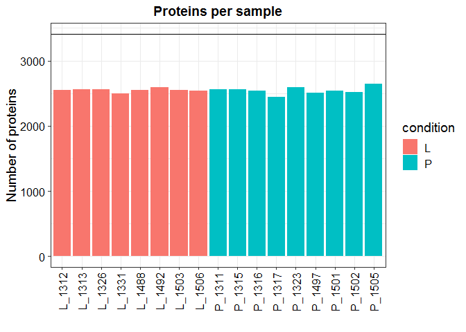

```r
plot_numbers(data_se)
```

Filter data for proteins detected in at least 5 samples in at least one group. Since the number of samples per group is not the same, we have to use fractions to get what we want. 55% will give at least 5 proteins in both groups.

```r
data_filt <- filter_proteins(data_se, type = "fraction", min = 0.55)

# Check the number of proteins left after filtering
kable(
  dim(data_filt)[1],
  col.names = "Number of proteins",
  align = "c",
  caption = "Proteins left after filtering",
  format = "pandoc"
)
```

Proteins left after filtering

| Number of proteins |
| --- |
| 2509 |

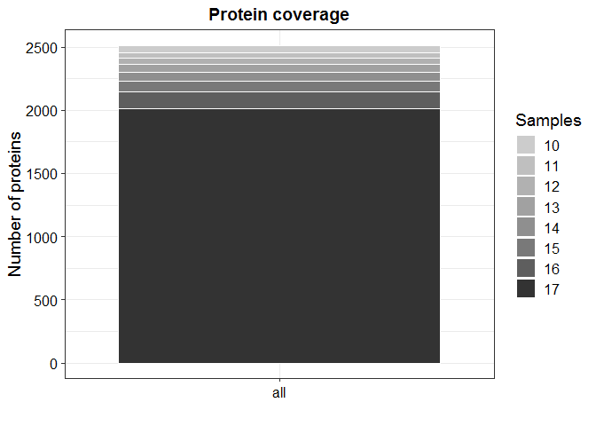

```r
plot_coverage(data_filt)
```

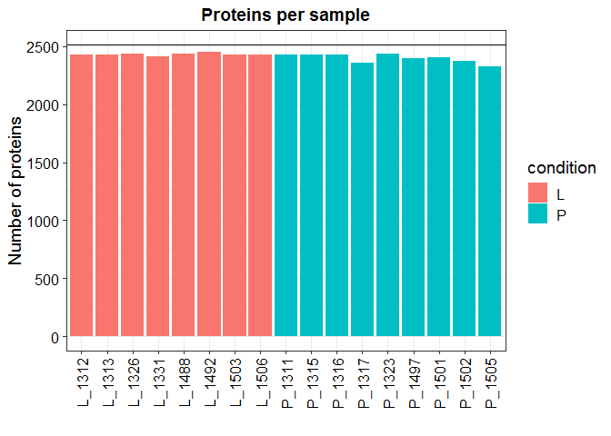

```r
plot_numbers(data_filt)
```

This is not what I wanted, after reading the documentation I found out that if you use “fraction” `filter_proteins` uses this fraction on all samples. That is not what I wanted. To do what I want, I need to filter before making a `SummarizedExperiment` object.

```r
data_filt <- data_unique %>%
  gather(key = "sample", value = "LFQ", `LFQ intensity L_1312`:`LFQ intensity P_1505`) %>%
  separate(sample, into = c("treatment", "sample"), sep = "_") %>%
  group_by(name, treatment) %>%
  dplyr::filter(sum(LFQ > 0) / length(LFQ) >= 0.55) %>%
  unite(sample, treatment, sample, sep = "_") %>%
  spread(key = sample, value = LFQ)

# Check the number of proteins left after filtering
kable(
  dim(data_filt)[1],
  col.names = "Number of proteins",
  align = "c",
  caption = "Proteins left after filtering",
  format = "pandoc"
)
```

Proteins left after filtering

| Number of proteins |
| --- |
| 2601 |

## Generate a summarizedExperiment object

```r
lfq_colnums <- grep("LFQ.", colnames(data_filt))

experimental_design <- read_tsv("experimental_design.txt")

data_se <- make_se(data_filt, lfq_colnums, experimental_design)
```

# Data exploration for the third time

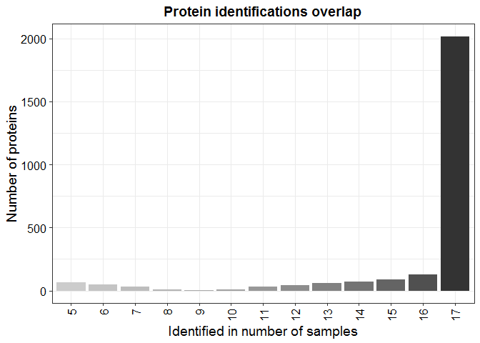

```r
plot_frequency(data_se)
```

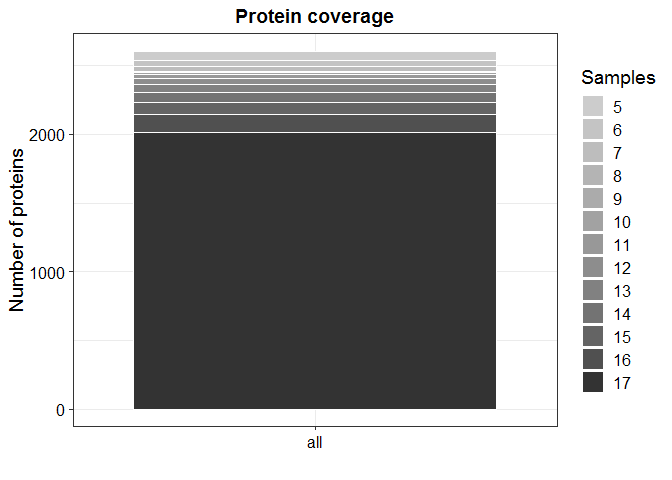

```r
plot_coverage(data_se)
```

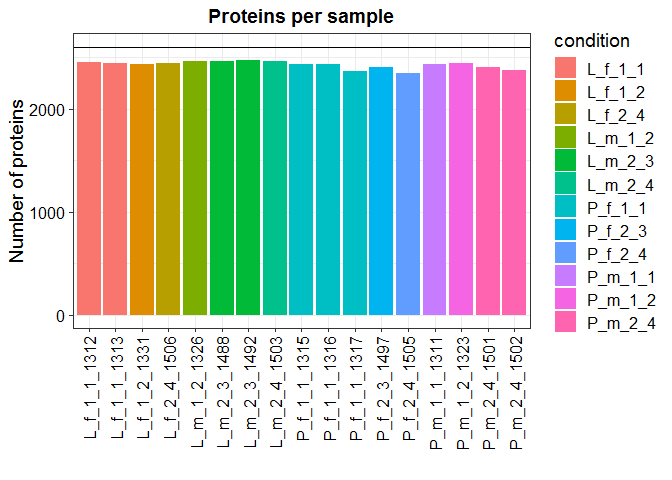

```r
plot_numbers(data_se)
```

## Normalization with vsn

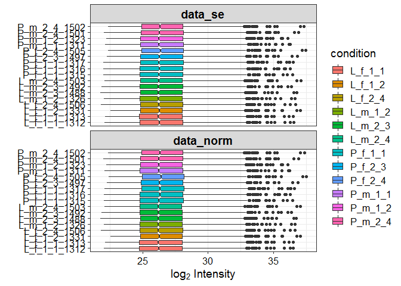

```r
data_norm <- normalize_vsn(data_se)

plot_normalization(data_se, data_norm)
```

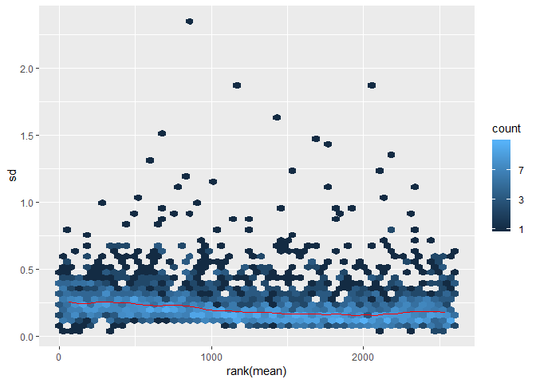

```r
meanSdPlot(data_se)
```

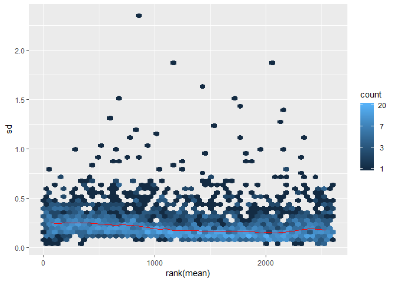

```r
meanSdPlot(data_norm)
```

When doing normalization after filtering it seems that more changes than before filtering. I should look up the function!

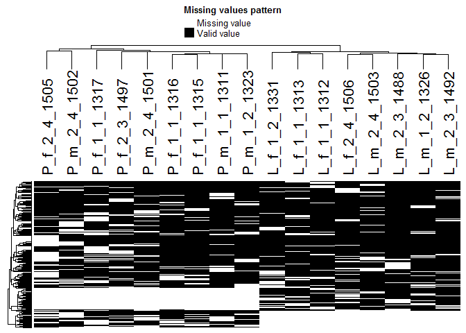

```r
# Plot missing values stats
plot_missval(data_norm)
```

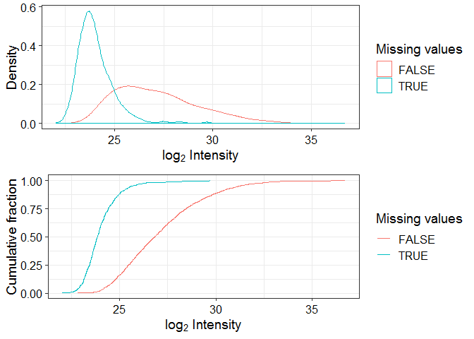

```r
plot_detect(data_norm)
```

From these plots, it would probably be interesting to see whether different imputation methods would give different results.

## Impute data

```r
# Impute missing data using random draws from a manually defined left-shifted
# Gaussian distribution (for MNAR). This is the default method in MaxQuant
data_imp_man <- impute(data_norm, fun = "man", shift = 1.8, scale = 0.3)
```

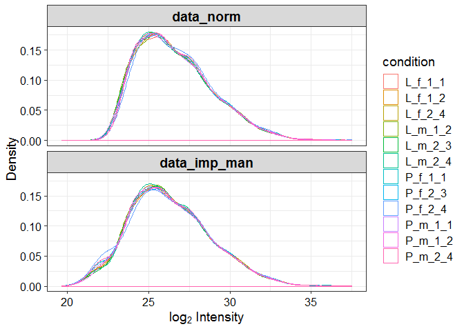

```r
# Plot imputation
plot_imputation(data_norm, data_imp_man)
```

These plots might be a bit misleading since we’re only interested in the treatment variable.